# An Introduction to Statistical Learning (2013)

Solutions to Exercises

by Brian Hassett

# Chapter 5 Conceptual Exercises

This notebook outlines solutions to the conceptual exercises in Chapter 5 of **An Introduction to Statistical Learning** (James et al. (2013)[^1]).

## Exercise 1

*Using basic statistical properties of the variance, as well as single-variable calculus, derive (5.6). In other words, prove that $\alpha$ given by (5.6) does indeed minimize $\operatorname{Var}(\alpha X + (1 - \alpha)Y)$.*

We seek to minimize $f(\alpha,X,Y)$ where
$$f(\alpha,X,Y)=\operatorname{Var}(\alpha X+(1-\alpha) Y)$$
From the basic properties of variance we have the following equality involving the variance of a sum of two random variables (see https://en.wikipedia.org/wiki/Variance#Basic_properties):
$$\operatorname{Var}(a X + b Y)=a^{2} \operatorname{Var}(X)+b^{2} \operatorname{Var}(Y) + 2 a b \operatorname{Cov}(X, Y)$$
Use this equality to rewrite $f(\alpha, X, Y)$:
$$f(\alpha, X, Y) = \alpha^2\operatorname{Var}(X) + (1-\alpha)^2\operatorname{Var}(Y) + 2 \alpha (1-\alpha) \operatorname{Cov}(X, Y)$$
Using the shorthand notation $\sigma^2_{X}=\operatorname{Var}(X)$, $\sigma^2_{Y}=\operatorname{Var}(Y)$ and $\sigma_{X Y}=\operatorname{Cov}(X, Y)$, we have:
$$f(\alpha, X, Y) = \alpha^2\sigma^2_{X} + (1-\alpha)^2\sigma^2_{Y} + 2 \alpha (1-\alpha) \sigma_{X Y}$$
The function $f(\alpha, X, Y)$ has a critical point where its derivative with respect to $\alpha$ is zero. Find $\frac{\partial f}{\partial\alpha}$ and set it equal to zero:
$$\frac{\partial}{\partial\alpha}\left(\alpha^2\sigma^2_{X} + (1-\alpha)^2\sigma^2_{Y} + 2 \alpha (1-\alpha) \sigma_{X Y}\right) = 0$$
$$\frac{\partial}{\partial\alpha}\left(\alpha^2\sigma^2_{X} + (1-2\alpha+\alpha^2)\sigma^2_{Y} + (2 \alpha-2\alpha^2) \sigma_{X Y}\right) = 0$$
$$2\alpha\sigma^2_{X} + (-2+2\alpha)\sigma^2_{Y} + (2-4\alpha) \sigma_{X Y} = 0$$
$$2\alpha\sigma^2_{X} - 2\sigma^2_{Y} + 2\alpha\sigma^2_{Y} + 2 \sigma_{X Y} - 4\alpha \sigma_{X Y} = 0$$
$$\alpha\sigma^2_{X} - \sigma^2_{Y} + \alpha\sigma^2_{Y} + \sigma_{X Y} - 2\alpha \sigma_{X Y} = 0$$
$$\alpha\sigma^2_{X} + \alpha\sigma^2_{Y} - 2\alpha \sigma_{X Y} = \sigma^2_{Y} - \sigma_{X Y}$$
$$\alpha(\sigma^2_{X} + \sigma^2_{Y} - 2\sigma_{X Y}) = \sigma^2_{Y} - \sigma_{X Y}$$
$$\alpha=\frac{\sigma_{Y}^{2}-\sigma_{X Y}}{\sigma_{X}^{2}+\sigma_{Y}^{2}-2 \sigma_{X Y}}$$
To make sure that this is indeed a minimum, we check that the second derivative of $f(\alpha, X, Y)$ with respect to $\alpha$ is positive:
$$\frac{\partial^2f}{\partial\alpha^2}=\frac{\partial^2}{\partial\alpha^2}\left(\alpha^2\sigma_{X}^{2} + (1-2\alpha+\alpha^2)\sigma_{Y}^{2} + (2 \alpha-2\alpha^2) \sigma_{X Y}\right)$$

$$\frac{\partial^2f}{\partial\alpha^2}=(2)\sigma_{X}^{2} + (2)\sigma_{Y}^{2} + (-4) \sigma_{X Y}$$
$$\frac{\partial^2f}{\partial\alpha^2}=2\sigma_{X}^{2} + 2\sigma_{Y}^{2} -4 \sigma_{X Y}$$
Rewrite $\frac{\partial^2f}{\partial\alpha^2}$ using the $\operatorname{Var}(.)$ and $\operatorname{Cov}(.)$ notation:
$$\frac{\partial^2f}{\partial\alpha^2}=2\operatorname{Var}(X) + 2\operatorname{Var}(Y) - 4\operatorname{Cov}(X,Y)$$
Use the above referenced equality involving the variance of a sum of two random variables:
$$\frac{\partial^2f}{\partial\alpha^2}=\operatorname{Var}(\sqrt{2}X-\sqrt{2}Y)$$
A basic property of variance is that it is non-negative, i.e. $\operatorname{Var}(.)\ge0$. This implies that
$$\frac{\partial^2f}{\partial\alpha^2} \ge 0$$
Since the second derivative is positive, we can say that the expression derived for $\alpha$ is indeed a minimum.$\hspace{2cm} \square$

## Exercise 2

*We will now derive the probability that a given observation is part of a bootstrap sample. Suppose that we obtain a bootstrap sample from a set of $n$ observations.*

1. *What is the probability that the first bootstrap observation is not the $j$th observation from the original sample? Justify your answer.*
2. *What is the probability that the second bootstrap observation is not the $j$th observation from the original sample?*
3. *Argue that the probability that the $j$th observation is not in the bootstrap sample is $(1 − 1/n)n$.*
4. *When $n = 5$, what is the probability that the $j$th observation is in the bootstrap sample?*
5. *When $n = 100$, what is the probability that the $j$th observation is in the bootstrap sample?*
6. *When $n = 10,000$, what is the probability that the $j$th observation is in the bootstrap sample?*
7. *Create a plot that displays, for each integer value of $n$ from $1$ to $100,000$, the probability that the $j$th observation is in the bootstrap sample. Comment on what you observe.*
8. *We will now investigate numerically the probability that a bootstrap sample of size $n = 100$ contains the $j$th observation. Here $j = 4$. We repeatedly create bootstrap samples, and each time we record whether or not the fourth observation is contained in the bootstrap sample.*

### (a)

Assuming that there is equal probability that each observation is chosen, the probability that the first bootstrap observation *is* the $j$th observation from the original sample is $1/n$. The probability that the first bootstrap observation is *not* the $j$th observation from the original sample is $(1-1/n)$.

### (b)

The probability that the second bootstrap observation is *not* the $j$th observation from the original sample is $(1-1/n)$. The probability that the first **and** second bootstrap observations are *not* the $j$th observation from the original sample is $(1-1/n)\times(1-1/n)=(1-1/n)^2$.

### (c)

The probability that the first bootstrap observation is *not* the $j$th observation from the original sample is $(1-1/n)$. The bootstrap samples with replacement, and each sample is independent, so the probability that each subsequent bootstrap observation is *not* the $j$th observation is also $(1-1/n)$. Therefore the probability that the $j$th observation is not in the bootstrap sample is $\prod_{i=1}^n(1-1/n)_{i}=(1-1/n)^n$.

### (d)

When $n = 5$, the probability that the $j$th observation is in the bootstrap sample is $1-(1-1/5)^5 = 0.67232$

### (e)

When $n = 100$, the probability that the $j$th observation is in the bootstrap sample is $1-(1-1/100)^{100} = 0.6339677$

### (f)

When $n = 10,000$, the probability that the $j$th observation is in the bootstrap sample is $1-(1-1/10,000)^{10,000} = 0.632139$

### (g)

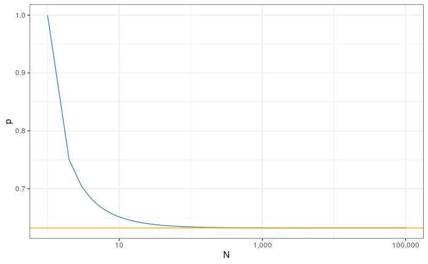

```r
N = 1:100000
p <- purrr::map_dbl(N, function(n) 1-(1-1/n)^n)

ggplot(data = data.frame(n = N, p),
         aes(N, p)) +
  geom_line(color = "steelblue") +
  geom_hline(yintercept = 1 - 1/exp(1),
             color = "orange") +
  scale_x_log10(labels = scales::comma)
```

We see that the probability approaches an asymptote as $n$ increases. This asymptote is $1-1/e$, i.e. $1-\lim_{n \rightarrow \infty}(1-1/n)^n$

### (h)

```r
set.seed(789)
store = rep(NA, 10000)
for(i in 1:10000) {
  store[i] = sum(sample(1:100, rep = TRUE) == 4) > 0
}
mean(store)
```

```
[1] 0.6372
```

We have a sample size of $n=100$. Therefore the probability that the $j$th observation is in the bootstrap sample is $0.6339677$. The value returned from the numerical simulation of $10,000$ bootstrap samples is $0.6372$, which is very close to the true value. The value from the simulation fluctuates a bit on each run. When the simulation is done with $100,000$ bootstrap samples a value of $0.63474$ was obtained, which is even closer to the true value:

```r
set.seed(789)
store = rep(NA, 100000)
for(i in 1:100000) {
  store[i] = sum(sample(1:100, rep = TRUE) == 4) > 0
}
mean(store)
```

```
[1] 0.63474
```

## Exercise 3

*We now review $k$-fold cross-validation.*

1. *Explain how $k$-fold cross-validation is implemented.*
2. *What are the advantages and disadvantages of $k$-fold cross-validation relative to:*
1. *The validation set approach?*
2. *LOOCV?*

### (a)

With *k*-fold cross-validation, the data is divided into $k$ training and test set pairs. If the data set has $n$ observations, then each training set has $(n-n/k)$ observations, while its corresponding test set contains the remaining $n/k$ observations. There are no overlapping observations in the $k$ test sets. However, the training sets will have overlapping observations between them.  
Once the data has been divided up into $k$ training and test set pairs, the learning method is applied to the each training set. The resulting model is then tested on the corresponding held-out test data. This results in $k$ measurements of the performance of the method. These $k$ measurements are then summed and divided by $k$ to give the *k*-fold cross-validation performance measure.

### (b)

*Adapted from ISLR (pages 183 & 184)*

#### (i)

The validation set approach has two main drawbacks compared to *k*-fold cross-validation. First, the validation estimate of the test error rate can be highly variable (depending on precisely which observations are included in the training set and which observations are included in the validation set). Second, only a subset of the observations are used to fit the model. Since statistical methods tend to perform worse when trained on fewer observations, this suggests that the validation set error rate may tend to overestimate the test error rate for the model fit on the entire data set.

#### (ii)

The LOOCV cross-validation approach is a special case of *k*-fold cross-validation in which $k=n$. This approach has two drawbacks compared to *k*-fold cross-validation. First, it requires fitting the potentially computationally expensive model n times compared to *k*-fold cross-validation which requires the model to be fitted only $k$ times. Second, the LOOCV cross-validation approach may give approximately unbiased estimates of the test error, since each training set contains $n−1$ observations; however, this approach has higher variance than *k*-fold cross-validation (since we are averaging the outputs of $n$ fitted models trained on an almost identical set of observations, these outputs are highly correlated, and the mean of highly correlated quantities has higher variance than less correlated ones). So, there is a bias-variance trade-off associated with the choice of $k$ in $k$-fold cross-validation; typically using $k=5$ or $k=10$ yields test error rate estimates that suffer neither from excessively high bias nor from very high variance.

## Exercise 4

*Suppose that we use some statistical learning method to make a prediction for the response $Y$ for a particular value of the predictor $X$. Carefully describe how we might estimate the standard deviation of our prediction.*

The bootstrap method can be used for this. This method allows us to obtain new data sets by repeatedly sampling, with replacement, from the original data set.

To estimate the standard deviation of the prediction, we would first repeat the bootstrap sampling process a large number of times (e.g. 10,000 times). Then, apply the method in question to each training set and use it to make a prediction. The standard deviation of the 10,000 predictions obtained is an estimate of the standard deviation our the prediction.

[^1]: James G, Witten D, Hastie T, Tibshirani R (2013). *An Introduction to Statistical Learning: with Applications in R*. Springer, 1st edition.